# Annotation and Annotation Resources

^ with content from Lori Shepherd Kern, Martin Morgan and James W. MacDonald **CSAMA 2026**

Johannes Rainer

Institute for Biomedicine, Eurac Research

# Introduction

## Data analysis

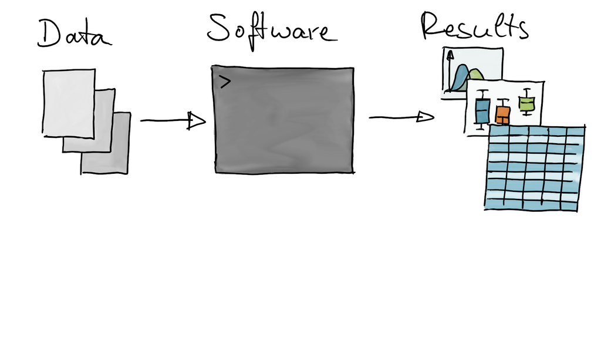

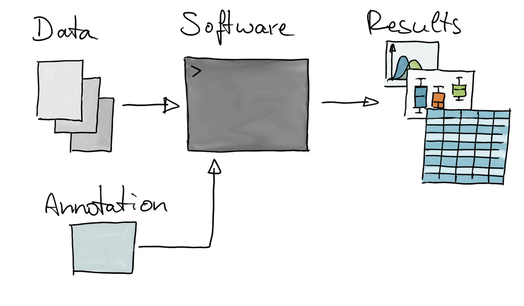

- *Annotation*: external data fed into an analysis to make *sense* of quantified entities.

## Annotation

- put a (new or different) label on an entity
- *entity*: something measured with an assay (RNA, molecule, cell)
- *label*: commonly used (standard) identifier (e.g. gene name)
- sounds trivial, but is very important task in computational biology
- examples:
  - map positions on the genome to transcripts
  - map genes to biological pathways
  - annotate cell types based on presence of marker genes
- 🎯 enable or assist in interpretation; make biological sense of assay data.

## In this presentation

- 1️⃣ provide some general information on annotation
- 2️⃣ give you an overview on available annotation resources
- 3️⃣ short use cases (with code)

1️⃣ General information on annotation

## What do we need for annotation?

- 1️⃣ an **annotation resource**: reference information on entities or a mapping of one type of identifiers to another.
- 2️⃣ a **rule** that defines how to assign labels to entities
  - annotation through similarity: sequence similarity, spectral similarity
  - direct mapping

## What do we need for annotation?

- 1️⃣ an **annotation resource**: reference information on entities or a mapping of one type of identifiers to another.
- 2️⃣ a **rule** that defines how to assign labels to entities
- *examples*
  - map between gene identifiers (Ensembl, NCBI, …)

## What do we need for annotation?

- 1️⃣ an **annotation resource**: reference information on entities or a mapping of one type of identifiers to another.
- 2️⃣ a **rule** that defines how to assign labels to entities
- *examples*
  - annotate through sequence similarity: map short reads to genome

## What do we need for annotation?

- 1️⃣ an **annotation resource**: reference information on entities or a mapping of one type of identifiers to another.
- 2️⃣ a **rule** that defines how to assign labels to entities
- *examples* (maybe through drawings?)
  - cell types through presence of marker genes

- ⚠️ there might be uncertainty in annotation

## Reproducibility

In order to guarantee **reproducibility** of annotation:

✅ annotation resource has to be **versioned** and **findable**

🙅 dynamic annotation resources (daily updates) without the possibility to access a specific version

✅ the **same version** should be used throughout the **whole** analysis

🙅 using a different genome release for RNA-seq alignment and gene counting.

## Standardization and metadata

- **Common nomenclature is required**
- It’s great if you can assign a name to an entity - but also other researchers should understand what you mean.
- *example*: synonyms

[figure not shown]

- Synonyms: aliases or previous names of entities.
- Can be tricky if different names are used across publications.
- 👉 use the official HGNC gene name!

## Standardization and metadata

- 🙀 … it can always be worse …

[figure not shown]

*Why?* annotation resource was compiled from community provided information.

- **Standardization and common nomenclature is important!**
- Standardization is important for human consumers, but even more so for computational use (including AI).

2️⃣ Annotation resources

## Annotation resources

- Where can you get annotations from?

## Annotation resources

**For genes**

- [NCBI](https://www.ncbi.nlm.nih.gov/), [Ensembl](https://ensembl.org), …

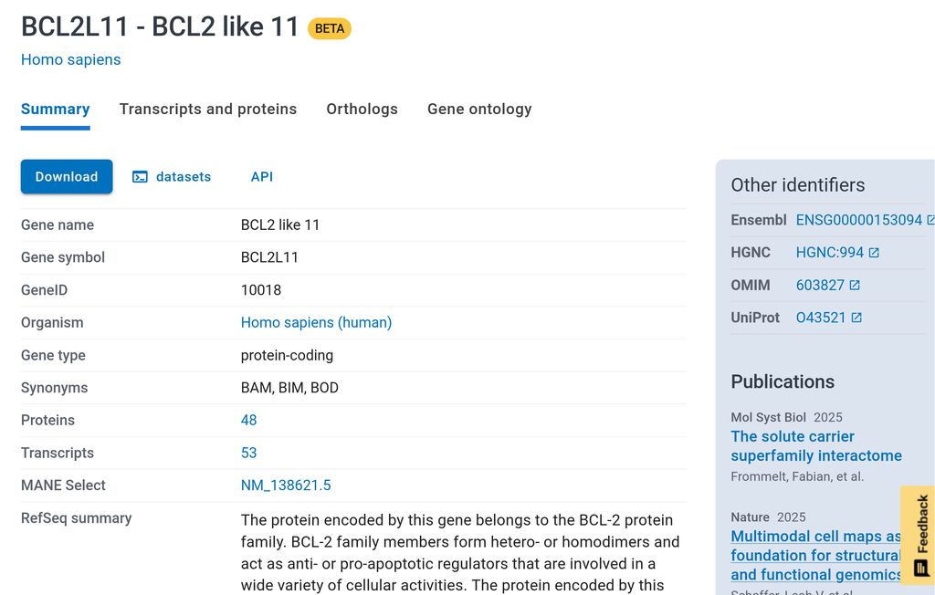

[figure not shown]

## Annotation resources

**For proteins**

- [UniProt](https://www.uniprot.org/), [Ensembl](https://ensembl.org), …

[figure not shown]

## Annotation resources

**For small molecules**

- [HMDB](https://hmdb.ca), [MassBank](https://massbank.eu), …

[figure not shown]

[figure not shown]

## Annotation resources

**Pathways**

- [reactome](https://reactome.org/), [wikipathways](https://www.wikipathways.org/), [KEGG](https://www.kegg.jp/)

[figure not shown]

## Annotation resources

**Pathways**

- [reactome](https://reactome.org/), [wikipathways](https://www.wikipathways.org/), [KEGG](https://www.kegg.jp/)

[figure not shown]

## Annotation resources

**Pathways**

- [reactome](https://reactome.org/), [wikipathways](https://www.wikipathways.org/), [KEGG](https://www.kegg.jp/)

[figure not shown]

- 😒 some annotation resources use their own data/file format making it cumbersome to include them in data analysis workflows.

## Bioconductor annotation resources

- Format standardized to simplify integration into the analysis (big thanks to the maintainers! 🙌)
- *AnnotationDbi* package defines a common interface to extract information from annotation resources: `mapIds()` and `select()` functions.

## Bioconductor annotation resources

[figure not shown]

- 💍 one to get them all: *AnnotationHub*

- Centrally managed annotation resources.

```r
library(AnnotationHub)

#' Synchronize and cache AnnotationHub information locally
ah <- AnnotationHub()
```

```r
#' List all available resources
ah
```

```
AnnotationHub with 5 records
# snapshotDate(): 2026-04-23
# $dataprovider: MassBank, TargetScan,miRTarBase,USCS,ENSEMBL, Ensembl
# $species: Homo sapiens, NA
# $rdataclass: CompDb, GRanges, EnsDb
# additional mcols(): taxonomyid, genome, description,
#   coordinate_1_based, maintainer, rdatadateadded, preparerclass, tags,
#   rdatapath, sourceurl, sourcetype
# retrieve records with, e.g., 'object[["AH98193"]]'

             title
  AH98193  | human_database
  AH107049 | MassBank CompDb for release 2022.06
  ...        ...
  AH119325 | Ensembl 113 EnsDb for Homo sapiens
  AH119519 | MassBank CompDb for release 2024.11
```

- ℹ️ many resources are community provided 💪.
- Resources come in variety of different formats and data types.

```r
#' List data class
table(ah$rdataclass)
```

```
 CompDb   EnsDb GRanges
      3       1       1
```

```r
query(ah, c("ensembl", "TwoBitFile"))
```

```
AnnotationHub with 0 records
# snapshotDate(): 2026-04-23
```

```r
ah["AH49592"]
```

```
AnnotationHub with 0 records
# snapshotDate(): 2026-04-23
```

- Or a dedicated R object.
- We retrieve one such object from *AnnotationHub*.

```r
query(ah, c("Hsapiens", "EnsDb"))
```

```
AnnotationHub with 1 record
# snapshotDate(): 2026-04-23
# names(): AH119325
# $dataprovider: Ensembl
# $species: Homo sapiens
# $rdataclass: EnsDb
# $rdatadateadded: 2024-10-28
# $title: Ensembl 113 EnsDb for Homo sapiens
# $description: Gene and protein annotations for Homo sapiens based on Ensem...
# $taxonomyid: 9606
# $genome: GRCh38
# $sourcetype: ensembl
# $sourceurl: http://www.ensembl.org
# $sourcesize: NA
# $tags: c("113", "Annotation", "AnnotationHubSoftware", "Coverage",
#   "DataImport", "EnsDb", "Ensembl", "Gene", "Protein", "Sequencing",
#   "Transcript")
# retrieve record with 'object[["AH119325"]]'
```

```r
edb <- ah[["AH119325"]]
edb
```

```
EnsDb for Ensembl:
|Backend: SQLite
|Db type: EnsDb
|Type of Gene ID: Ensembl Gene ID
|Supporting package: ensembldb
|Db created by: ensembldb package from Bioconductor
|script_version: 0.3.10
|Creation time: Sat Oct 26 21:34:14 2024
|ensembl_version: 113
|ensembl_host: 127.0.0.1
|Organism: Homo sapiens
|taxonomy_id: 9606
|genome_build: GRCh38
|DBSCHEMAVERSION: 2.2
|common_name: human
|species: homo_sapiens
| No. of genes: 87726.
| No. of transcripts: 413674.
|Protein data available.
```

- First time data is downloaded, subsequent calls will load the data from the cache 💪

## Bioconductor annotation resources

- … and there are also dedicated R packages with specific annotations.
- *example*: identifiers and metadata for human genes.

```r
library(org.Hs.eg.db)
org.Hs.eg.db
```

```
OrgDb object:
| DBSCHEMAVERSION: 2.1
| Db type: OrgDb
| Supporting package: AnnotationDbi
| DBSCHEMA: HUMAN_DB
| ORGANISM: Homo sapiens
| SPECIES: Human
| EGSOURCEDATE: 2026-Mar18
| EGSOURCENAME: Entrez Gene
| EGSOURCEURL: ftp://ftp.ncbi.nlm.nih.gov/gene/DATA
| CENTRALID: EG
| TAXID: 9606
| GOSOURCENAME: Gene Ontology
| GOSOURCEURL: https://current.geneontology.org/ontology/go-basic.obo
| GOSOURCEDATE: 2026-01-23
| GOEGSOURCEDATE: 2026-Mar18
| GOEGSOURCENAME: Entrez Gene
| GOEGSOURCEURL: ftp://ftp.ncbi.nlm.nih.gov/gene/DATA
| KEGGSOURCENAME: KEGG GENOME
| KEGGSOURCEURL: ftp://ftp.genome.jp/pub/kegg/genomes
| KEGGSOURCEDATE: 2011-Mar15
| GPSOURCENAME: UCSC Genome Bioinformatics (Homo sapiens)
| GPSOURCEURL: ftp://hgdownload.cse.ucsc.edu/goldenPath/hg38/database
| GPSOURCEDATE: UTC-Mar19
| ENSOURCEDATE: 2025-Sep03
| ENSOURCENAME: Ensembl
| ENSOURCEURL: ftp://ftp.ensembl.org/pub/current_fasta
| UPSOURCENAME: Uniprot
| UPSOURCEURL: http://www.UniProt.org/
| UPSOURCEDATE: Fri Mar 20 10:22:53 2026
```

- Most annotation resources provide mapping between gene identifiers or mapping to e.g. pathways.

## Position-relative annotations

- Mapping between entities (genes, exons) and positions (on the genome, within a transcript).
- `GenomicFeatures::TxDb` resources.

## Position-relative annotations

[figure not shown]

- Mapping between entities (genes, exons, **protein domains**) and positions (on the genome, within a transcript, within a **protein**).
- `GenomicFeatures::TxDb` and `ensembldb::EnsDb` resources.

## Position-relative annotations

[figure not shown]

- Mapping between entities (genes, exons, protein domains) and positions (on the genome, within a transcript, within a protein).
- `GenomicFeatures::TxDb` and `ensembldb::EnsDb` resources.
- Organism and release-specific data (SQLite databases).
- Positional information: genomic position of exons

```r
exons(edb)
```

```
GRanges object with 1131826 ranges and 1 metadata column:
                  seqnames            ranges strand |         exon_id
                     <Rle>         <IRanges>  <Rle> |     <character>
  ENSE00004248723        1       11121-11211      + | ENSE00004248723
  ENSE00004248721        1       11125-11211      + | ENSE00004248721
              ...      ...               ...    ... .             ...
  ENSE00004286596        Y 57215558-57215594      - | ENSE00004286596
  ENSE00004286597        Y 57215558-57215634      - | ENSE00004286597
  -------
  seqinfo: 540 sequences (1 circular) from GRCh38 genome
```

3️⃣ Use cases

## Annotation RNA-seq, raw reads

- *example* (Love et al. 2015):
  - bulk RNA-seq data
  - alignment against genome using [STAR](https://code.google.com/p/rna-star/)

```r
library(airway)
dir(system.file("extdata", package = "airway"))
```

```
 [1] "GSE52778_series_matrix.txt"        "Homo_sapiens.GRCh37.75_subset.gtf"
 [3] "quants"                            "sample_table.csv"
 [5] "SraRunInfo_SRP033351.csv"          "SRR1039508_subset.bam"
 [7] "SRR1039509_subset.bam"             "SRR1039512_subset.bam"
 [9] "SRR1039513_subset.bam"             "SRR1039516_subset.bam"
[11] "SRR1039517_subset.bam"             "SRR1039520_subset.bam"
[13] "SRR1039521_subset.bam"
```

- *task*: quantifying reads per gene.
- *required*: positional (genome) information for genes (exons)
- 👉 get annotation resource for genome version / Ensembl release.

```r
library(EnsDb.Hsapiens.v75)
edb <- EnsDb.Hsapiens.v75
```

- Get positional information for exons

```r
exns <- exonsBy(edb, by = "gene")
exns
```

```
GRangesList object of length 64102:
$ENSG00000000003
GRanges object with 17 ranges and 1 metadata column:
       seqnames            ranges strand |         exon_id
          <Rle>         <IRanges>  <Rle> |     <character>
   [1]        X 99894942-99894988      - | ENSE00001828996
   [2]        X 99891790-99892101      - | ENSE00001863395
   ...      ...               ...    ... .             ...
  [16]        X 99885756-99885863      - | ENSE00000868868
  [17]        X 99883667-99884983      - | ENSE00001459322
  -------
  seqinfo: 273 sequences (1 circular) from GRCh37 genome

...
<64101 more elements>
```

- Get the BAM files with the alignment results for the present experiment.

```r
#' Get the BAM file names in the *airway* package
f <- dir(system.file("extdata", package = "airway"),
         pattern = "bam$", full.names = TRUE)

library("Rsamtools")
bamfiles <- BamFileList(f, yieldSize = 2000000)
```

- Use `GenomicAlignments::summarizeOverlaps()` to count reads falling within exon boundaries.

```r
library(GenomicAlignments)
se <- summarizeOverlaps(features = exns, reads=bamfiles,
                        mode = "Union", singleEnd = FALSE,
                        ignore.strand = TRUE,
                        fragments = TRUE)
se
```

```
class: RangedSummarizedExperiment
dim: 64102 8
metadata(0):
assays(1): counts
rownames(64102): ENSG00000000003 ENSG00000000005 ... LRG_98 LRG_99
rowData names(0):
colnames(8): SRR1039508_subset.bam SRR1039509_subset.bam ...
  SRR1039520_subset.bam SRR1039521_subset.bam
colData names(0):
```

- Result: gene count data.
- ℹ️ afternoon labs will use an updated workflow using *Salmon* for alignment against the transcriptome and the *tximeta* Bioconductor package for managing data and annotation resources.

## Annotating gene information

- Common task in annotation: add additional metadata to existing identifiers.
- *example*: bulk RNA-seq data *airway*:

```r
se
```

```
class: RangedSummarizedExperiment
dim: 64102 8
metadata(0):
assays(1): counts
rownames(64102): ENSG00000000003 ENSG00000000005 ... LRG_98 LRG_99
rowData names(0):
colnames(8): SRR1039508_subset.bam SRR1039509_subset.bam ...
  SRR1039520_subset.bam SRR1039521_subset.bam
colData names(0):
```

- ℹ️ gene quantification data, 8 samples.
- What gene identifiers do we have?

```r
#' extract gene identifiers
ids <- rownames(se)
head(ids)
```

```
[1] "ENSG00000000003" "ENSG00000000005" "ENSG00000000419" "ENSG00000000457"
[5] "ENSG00000000460" "ENSG00000000938"
```

- We’ve got Ensembl gene IDs.
- *task*: get official HGNC gene symbols (names) the genes.
- 👉 use `AnnotationDbi::mapIds()` with *org.Hs.eg.db*.

```r
library(org.Hs.eg.db)
#' available gene annotations:
columns(org.Hs.eg.db)
```

```
 [1] "ACCNUM"       "ALIAS"        "ENSEMBL"      "ENSEMBLPROT"  "ENSEMBLTRANS"
 [6] "ENTREZID"     "ENZYME"       "EVIDENCE"     "EVIDENCEALL"  "GENENAME"
[11] "GENETYPE"     "GO"           "GOALL"        "IPI"          "MAP"
[16] "OMIM"         "ONTOLOGY"     "ONTOLOGYALL"  "PATH"         "PFAM"
[21] "PMID"         "PROSITE"      "REFSEQ"       "SYMBOL"       "UCSCKG"
[26] "UNIPROT"
```

```r
symbols <- mapIds(org.Hs.eg.db, keys = ids, keytype = "ENSEMBL",
                  column = "SYMBOL", multiVals = "first")
head(symbols)
```

```
ENSG00000000003 ENSG00000000005 ENSG00000000419 ENSG00000000457 ENSG00000000460
       "TSPAN6"          "TNMD"          "DPM1"         "SCYL3"         "FIRRM"
ENSG00000000938
          "FGR"
```

- `multiVals`… to handle ambiguity; default is `"first"` but there are other options too.
- ℹ️ that’s one way; we could also use *ensembldb*’s `EnsDb` resources (to ensure we use the same release versions).

```r
symbols <- mapIds(edb, keys = ids, keytype = "GENEID",
                  column = "SYMBOL", multiVals = "first")
```

## Annotation for enrichment analysis

- 🎯 going one step further … annotating genes to biological pathways.

## Annotation for enrichment analysis

- Enrichment analysis for biological pathways from [reactome](https://reactome.org).
- *example*: use the *reactome.db* package to get the list of genes per pathway.

```r
library(reactome.db)

#' Available data
columns(reactome.db)
```

```
[1] "ENTREZID"   "GO"         "PATHID"     "PATHNAME"   "REACTOMEID"
```

- ℹ️ gene identifiers: NCBI EntrezGene IDs.
- get gene and pathway IDs for all genes.

```r
mapping <- select(reactome.db, keys = keys(reactome.db),
                  columns = c("ENTREZID", "PATHID"))
head(mapping)
```

```
  ENTREZID        PATHID
1        1  R-HSA-109582
2        1  R-HSA-114608
3        1  R-HSA-168249
4        1  R-HSA-168256
5        1 R-HSA-6798695
6        1   R-HSA-76002
```

- Convert into a `list` of genes per pathway.

```r
gs <- split(mapping$ENTREZID, mapping$PATHID)
gs[1:2]
```

```
$`R-BTA-1059683`
[1] "280826" "282081" "507359" "512484" "527418" "533590"

$`R-BTA-109581`
 [1] "100101492" "100140945" "100296226" "280730"    "280955"    "281020"
 [7] "281048"    "281169"    "282125"    "282126"    "282152"    "282321"
[13] "282691"    "286862"    "286863"    "287022"    "327672"    "404144"
[19] "404151"    "407101"    "407111"    "408016"    "493720"    "493999"
[25] "504707"    "504727"    "506223"    "507481"    "507804"    "507981"
[31] "508345"    "508646"    "510373"    "510767"    "512405"    "514090"
[37] "516952"    "517850"    "528453"    "529902"    "531514"    "533233"
[43] "533527"    "533949"    "538801"    "539003"    "539350"    "539679"
[49] "539941"    "540108"    "540369"    "540444"    "540643"    "540892"
[55] "541141"    "614840"    "616398"    "768311"    "785911"
```

- Annotate the Ensembl gene IDs to NCBI EntrezGene IDs with `mapIds()`.

```r
entrez <- mapIds(edb, keys = rownames(se), keytype = "GENEID",
                 column = "ENTREZID", multiVals = "first")
```

- 👉 use this definition of gene sets in enrichment functions, such as `EnrichmentBrowser::sbea()` or others.

```r
library(EnrichmentBrowser)

rownames(se) <- entrez
#' ... assuming differential expression analysis was done too ...
res <- sbea(method = "ora", se, gs = gs)
```

- ℹ️ *EnrichmentBrowser* makes the mapping easier with its`idMap()` and `getGenesets()` functions.

## Annotating mass spectrometry data

- … more on that on Thursday …

## Annotating cell types

- single cell things.
- presence of marker genes.

**Thank you for your attention 🙌**

## References

Love, Michael I., Simon Anders, Vladislav Kim, and Wolfgang Huber. 2015. “RNA-Seq Workflow: Gene-Level Exploratory Analysis and Differential Expression.” *…* 4: 1070. https://doi.org/10.12688/f1000research.7035.1.